# Transmission effect on fuel consumption

Balint SZEBENYI

2015-08-13

# Executive summary

This document is an attempt to quantify the relationship between fuel consumption and transmission. It has been found that this relationship is non-existant on the ‘mtcars’ database. There are other factors like weight and engine parameters that are crucial when it comes to fuel consumption but transmission alone is not a reason for difference - based on the available data. A paired sample that uses the same models with all parameters equal except transmission is the only viable way to quantify a difference if it exists.

# Exploratory analysis

The dataset, which was examined is the mtcars dataset that is distributed with R. The original data description is found at https://stat.ethz.ch/R-manual/R-devel/library/datasets/html/mtcars.html, this is only a brief summary.

The relationship between the variables can be illustrated via the following plot. Other variables were omitted from the plot for they have shown linear correlation coefficients with relatively middle (0.5-0.6) strength.

Outliers have not been searched for, the dataset is assumed to be clean for analyis being a default dataset.

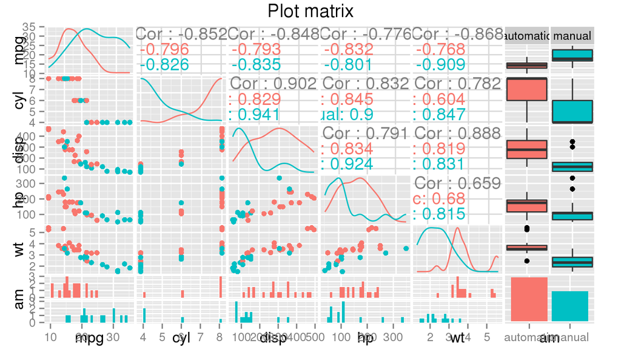

The plot reveals us that there is a relative strong correlation between fuel consumption and the selected variables. By looking at the connection between transmission methods it is visible that manual transmission methods are likely to be present in vehicles that have a higher miles per gallon performance. It is also an observable tendency that vehicles with a lower weight and lower cylinders tend to use manual transmission. This is a crucial information in our analysis.

# Modeling

*The model’s summary are not included but since the analysis is available via github and knitr, they can be obtained any time. The important parameters of the models’ have been cited in the text though.*

The first model will be the simplest model. It just includes the binary variable “am” for transmission to try to explain the variation in fuel consumption “mpg”. This is actually nothing more than seeing if the group of automatic vehicles and manual vehicles have a difference in their consumption, by observing just this characteristic of the vehicle.

```r
fit1 <- lm(mpg ~ am, data = df)
```

It is found that approximately 36% percent of the variation in fuel consumption can be explained just by knowing which group a car belongs to. Observing only the relevant boxplot it seems that a distinction can be made between the automatic and manual transmission equipped vehicles, however the two datasets overlap more than the interquantile ranges denoted by boxes on the boxplot would suggest. As an illustration of this statement see the violin plot next to the boxplot.

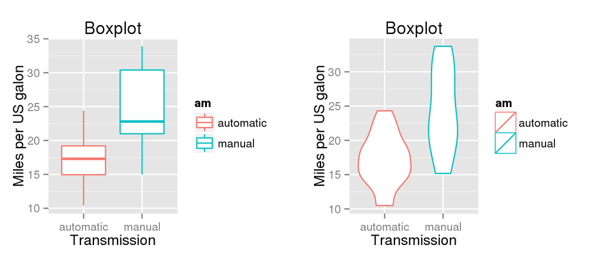

```r
g <- ggplot(data=df) + geom_boxplot(mapping = aes(x = am, y = mpg, colour = am)) + labs(title = "Boxplot", x = "Transmission", y = "Miles per US galon")
h <- ggplot(data=df) + geom_violin(mapping = aes(x = am, y = mpg, colour = am)) + labs(title = "Boxplot", x = "Transmission", y = "Miles per US galon")
grid.arrange(g, h, ncol = 2)
```

However, it is very likely (based on the first plot of the study and the strong linear correlation coefficients between the variables) that there are confounding factors and transmission by itself is not decisive. This means that transmission could be determined through other physical aspects of a vehicle and it were itself not a cause of higher or lower fuel consumption.

```r
fit2 <- lm(mpg ~ am + hp, data = mtcars)
```

By fitting a regression that includes one additional explanatory variable, the horsepower, the model gets significantly better. The uncertainty regarding the variance in fuel consumption can be reduced by 78.2 percent just by having information about these two aspects of a vehicle. Both the model and the variables individually are significant on all usual significance levels. The question still remains, whether the performance can be improved even further.

```r
fit3 <- lm(mpg ~ am + wt + hp + cyl + disp, data = mtcars)
```

By adding more explanatory variables (the weight, the number of cylinders, the displacement) the model fails. Overall the model is still showing a significant F-statistic, however many of the variables are not significant, including transmission! This renders model 3 useless.

```r
fit4 <- lm(mpg ~ am + wt + hp, data = mtcars)
```

By trying to remove the insignificant variables but keeping transmission in the model it was visible that transmission by itself has not become significant which suggests that transmission does not have a measurable effect on fuel consumption.

```r
fit5 <- lm(mpg ~ wt + hp, data=mtcars)
```

Taking it one step even further the previous statement is supported by the R-squared values of model 4 and 5. Omitting the transmission information the model’s performance has stayed almost the same, with R-squared 0.84 for model 4, and 0.827 for model 5. (Even though the adjusted R-squared value is higher in the case of model 4, the “am”" variable is insignificant.)

```r
fit6 <- lm(mpg ~ am + hp + I(am*hp), data = mtcars)
```

The summary of model 6 reveals that this has not improved the model at all. Therefore only model 2 is left for prediction as the “best” model, but it is also a useless model, which is not supposed to be used to decide whether a vehicle will have a higher consumption based on its transmission, because of confounding that has been shown before.

```r
fit2$coefficients
```

```
## (Intercept)          am          hp
##  26.5849137   5.2770853  -0.0588878
```

```r
confint(fit2)
```

```
##                   2.5 %      97.5 %
## (Intercept) 23.67026866 29.49955884
## am           3.06917692  7.48499369
## hp          -0.07495665 -0.04281896
```

The model reveals that ceteris paribus (leaving everything else intact) switching a vehicle’s transmission from automatic (0) to manual (1) the expected miles that the vehicle can run per (US) gallon will increase on by 5.277. This value is however not an exact value. This value lies between 3.07 and 7.49 at a significance level of 5 percent. Once again, this is not to be taken as an effect of the transmission but rather as the effect of weight and other engine parameters that are tendentially present when the transmission is manual.

To evaluate this best-but-do-not-use model, first the model itself is plotted, then the residuals.

```r
df <- df %>%
  mutate(fit2predicted = predict(fit2))
```

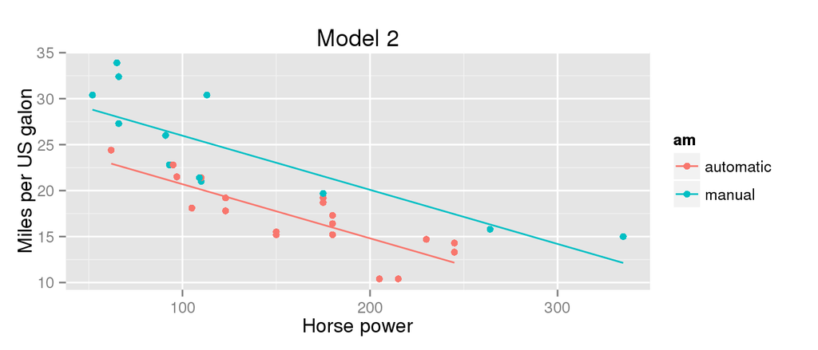

```r
g <- ggplot(data = df)
g <- g + geom_line(aes(x = hp, y = fit2predicted, colour = am))
g <- g + geom_point(aes(x = hp, y = mpg, colour = am))
g <- g + labs(title = "Model 2", x = "Horse power", y = "Miles per US galon")
plot(g)
```

It is visible that there is a negative tendency between horsepower and available miles that can be reached with a single gallon. It should be mentioned again that the transmission seems to make a difference in the slope’s intersect but there are confounding factors that lead to this.

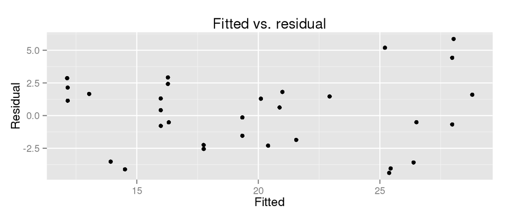

```r
ggplot(fortify(fit2), aes(.fitted, .resid)) + geom_point() + labs(title = "Fitted vs. residual", x = "Fitted", y = "Residual")
```

The reiduals do not show a clean pattern, which would signal additional extractable information in the variables. Therefore the model is acceptable, but still, not usable due to confounding.

# Summary

It has been shown that transmission by itself does not effect fuel consumtion. This result is only valid for this dataset. There is more to be discovered about fuel consumption but this dataset can only justify this result. Further research could use principal component analysis to group together variables that are bound together. Another possibility would be to use binary logistic regression to find out what influences transmission category the most. Last, but not least a paired dataset where the same model is equipped with manual and automatic transmission is the only viable path to grab the effect of transmission on fuel consumption.